### California sea lion pups

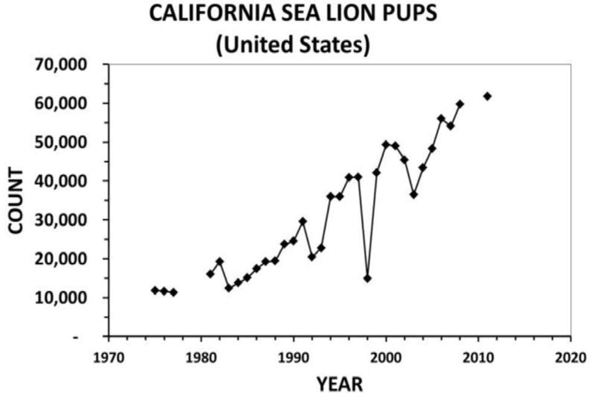

**Click for Details**

U.S. pup count index for California sea lions *Zalophus californianus* (1975–2011). Trends in pup counts from 1975–2011 are shown for four rookeries in southern California and for haulouts in central and northern California. Figure: Carretta et al. 2016

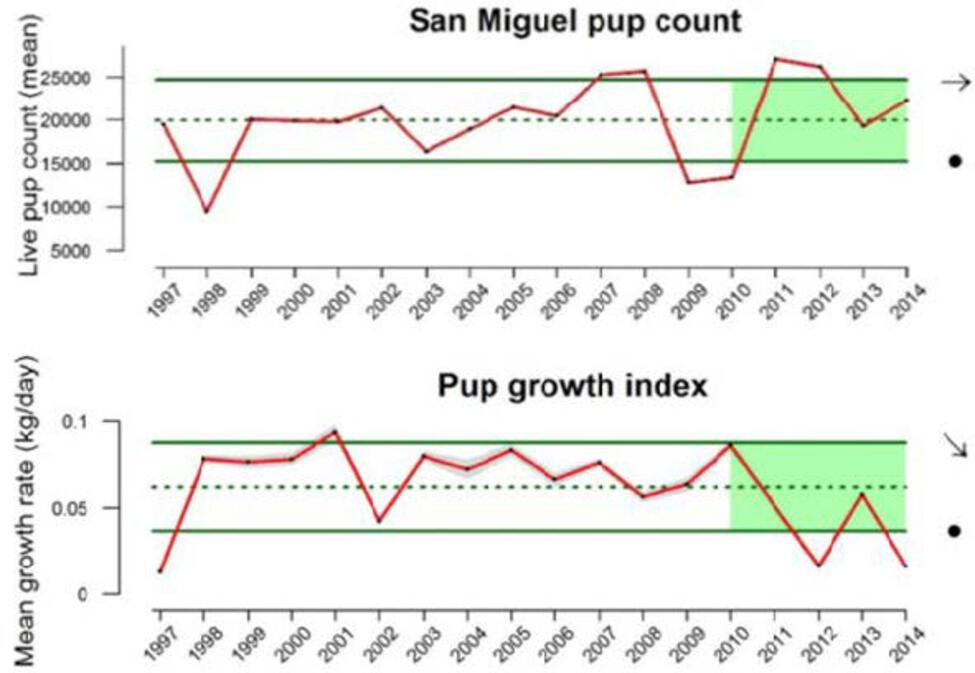

**Figure App.F.13.24.**. A figure showing live pup counts (top) and average pup growth (bottom) for California sea lion pups on San Miguel Island from 1997 - 2014.

**Click for Details**

Live pup count (top) and mean pup growth index for California sea lions *Zalophus californianus* (1997–2014). Recent trends in pup counts have been stable, but declining for pup growth likely due to low availability of prey resources in central and southern California, which is the foraging range of nursing females. Symbols on graph are explained in the caption of Figure App.F.12.18. Figure: NMFS 2016a

### Harbor seals (*Phoca vitulina*)

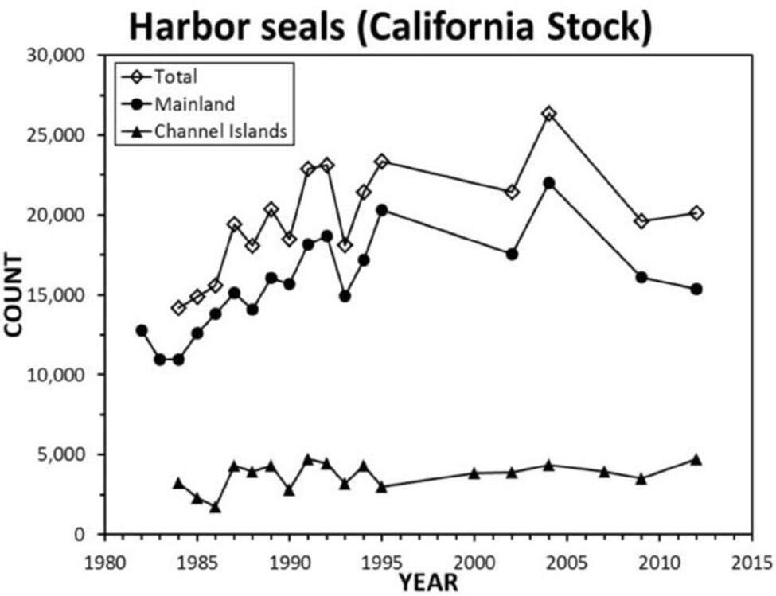

**Click for Details**

Population size of harbor seals *Phoca vitulina* in California is estimated by counting the number of seals ashore during the peak haulout period (May to July) and by multiplying this count by a correction factor. The population on Channel Islands beaches (triangle) appears to be stable. Figure: Carretta et al. 2016

### Northern elephant seals (*Mirounga angustirostris*)

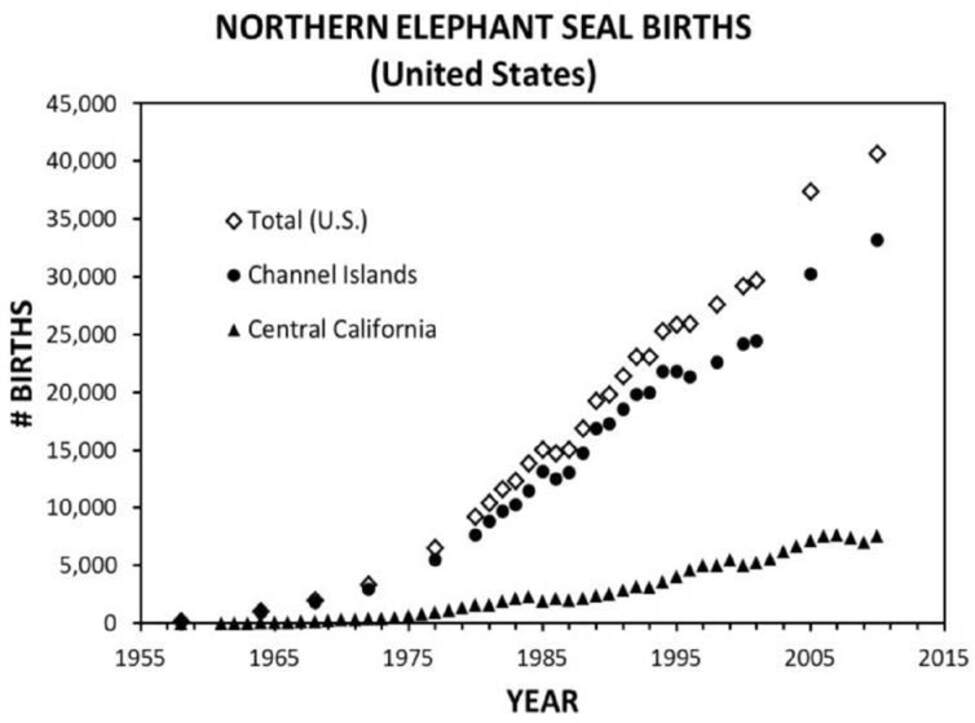

**Figure App.F.13.26.**. A figure showing the estimated number of northern elephant seal births from 1958 - 2010 on the Channel Islands and in Central California.

**Click for Details**

Estimated number of northern elephant seal *Mirounga angustirostris* births in California from 1958–2010. There has been an increasing trend over the entire time series for Channel Islands (circles). Elephant seals have increased in abundance and taken up residence at locations on Santa Rosa Island that have historically not been inhabited (S. Whitaker, CINP, pers. comm.). Figure: Carretta et al. 2016

### Northern fur seals (*Callorhinus ursinus*)

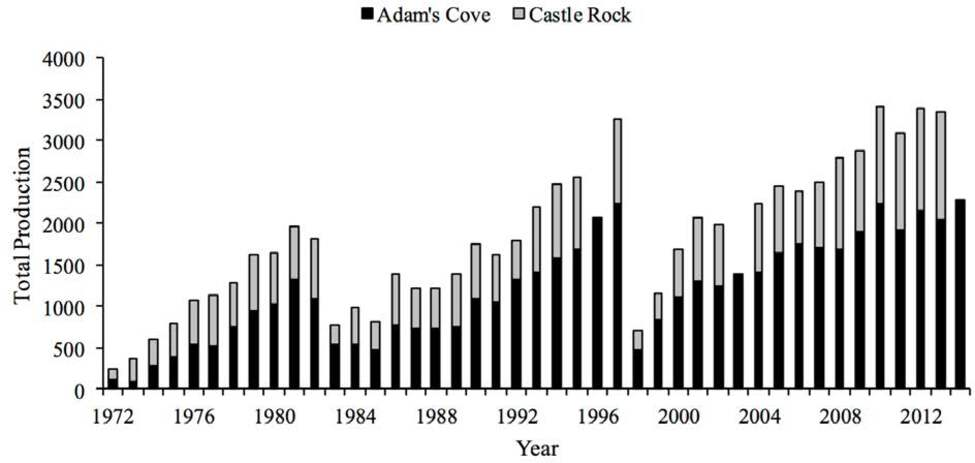

**Figure App.F.13.27.**. A figure showing the number of Northern fur seal pups counted at two locations on San Miguel Island from 1972 - 2014.

**Click for Details**

Total production of Northern fur seal *Callorhinus ursinus* pups counted on San Miguel Island, including the mainland (Adam’s Cove) and the offshore islet (Castle Rock), from 1972–2014. The total production of northern fur seals exceeded the 1997 levels during 2010, 2012, and 2013. The island’s population has recovered from the 1997–1998 El Niño event. Figure: Carretta et al. 2016